# Evaluating tree competition indices as predictors of basal area increment in western Montana forests - ScienceDirect

## Figures (9)

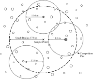

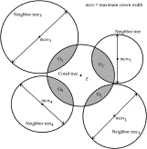

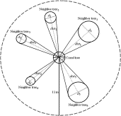

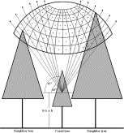

## [Forest Ecology and Management](https://www.sciencedirect.com/science/journal/03781127)

[Volume 262, Issue 11](https://www.sciencedirect.com/science/journal/03781127/262/11), 1 December 2011, Pages 1939-1949

# Evaluating tree competition indices as predictors of basal area increment in western Montana forests

[Marco A.Contreras<sup>a</sup>](https://www.sciencedirect.com/science/article/pii/S0378112711005238#!)[DavidAffleck<sup>b</sup>](https://www.sciencedirect.com/science/article/pii/S0378112711005238#!)[WoodamChung<sup>b</sup>](https://www.sciencedirect.com/science/article/pii/S0378112711005238#!)

https://doi.org/10.1016/j.foreco.2011.08.031[Get rights and content](https://s100.copyright.com/AppDispatchServlet?publisherName=ELS&contentID=S0378112711005238&orderBeanReset=true)

## Abstract

Fire hazard reduction treatments are commonly applied to mixed-species coniferous forests in western Montana, USA, to modify fuels structures and alter the competitive environments of individual trees. An improved understanding of how competition can be measured and how it conditions individual tree growth is needed for projecting the development of these forests, with and without treatment. Numerous studies have evaluated how competition affects tree growth and many indices have been developed to quantify the competition an individual tree experiences. These studies suggest that no single competition index or a single class of indices is universally superior; indices perform differently according to forest type and forest conditions. We chose several widely used distance-independent and distance-dependent competition indices, and also derived anisotropic distance-dependent indices from estimates of light interception by tree crowns. We evaluated the effectiveness of these competition measures for predicting basal area increment (BAI) of *Pinus ponderosa*, *Pseudotsuga menziesii*, and *Larix occidentalis* in western Montana. The best distance-dependent competition indices explained a larger proportion of growth variation than the best distance-independent indices (64% vs. 56%). This result indicates that competition is an important growth determinant in these forests and that competition varies locally, with variable tree densities and relatively complex stand structures creating heterogeneous neighborhood conditions. Competition indices derived from light interception models were only weakly correlated with other indices and performed poorly in terms of predicting tree growth. This result accords with previous observations that competition for light is not the primarily growth limitation for trees in the semi-arid conditions of western Montana. More sophisticated light availability models could be used to better assess variability in light interception and its marginal contribution to predictive accuracy of radial tree growth. Diameter and distance-dependent BAI models were developed for growth prediction at the species level and for all species combined.

### Highlights

► We evaluated competition indices as predictors of tree growth for conifer species. ► Distance-dependent indices were more strongly correlated with tree growth. ► Light-interception indices were only weakly correlated with tree growth. ► Results indicate that competition is an important growth factor in these forests.

## Keywords

Individual-tree growth

Competition

Light interception

Gamma regression

Montana

## 1. Introduction

The montane coniferous forests of western Montana and much of the inland northwest have experienced a century of fire suppression, and wildfire hazard mitigation has emerged as a primary management consideration across the region. Fire suppression, together with past logging and grazing practices, has led to material changes in forest structure, composition, and function (see e.g., Keane et al., 2002, MacKenzie et al., 2004). In particular, over vast areas much higher stand densities have been achieved than were common in the past, largely through increased recruitment of more shade-tolerant species (Habeck, 1994, Keane et al., 2002). Fire hazard reduction and restoration treatments in the region often take the form of selective logging or thinning operations that modify forest structure and, among other things, the competitive environments of remnant trees. Thus current growing conditions and common fuel treatment practices are creating and maintaining complex, heterogeneous stands. Individual tree models are needed to credibly forecast the development of these stands and the effects of hazard reduction treatments. Such models, in turn, require an improved understanding of how tree competition should be quantified and of how it conditions tree growth.

Measures of tree competition are commonly among the most important predictors of individual tree growth (Radtke et al., 2003). Competition among trees can be defined as the negative effects of neighbor trees on a subject tree resulting from their consumption, or regulation of access to, limited resources such as light, water, and nutrients (Keddy, 1989). Numerous studies have developed indices to quantify the level of competition an individual tree experiences and have evaluated how these affect growth rates (Bella, 1971, Moore et al., 1973, Tomé and Burkhart, 1989, Holmes and Reed, 1991, Biging and Dobbertin, 1992, De Luis et al., 1998). Most competition indices described in the literature can be divided into two classes: (i) distance-independent indices that use only non-spatial information about aggregate tree size and number within a given area (e.g., a plot or stand), and (ii) distance-dependent indices that also incorporate the relative locations of neighboring trees within the area. Recently, another class of competition measures called semi-distance-independent has been developed (Stage and Ledermann, 2008, Lederman, 2010). These measures apply distance-independent calculations but spatially constrain the set of candidate neighbor trees based on the location of inventory plots. The motivation for semi-distance-independent indices stems from the fact that traditional, sample-based inventory data are populated from sets of trees in inventory plots and information on competitors growing off-plot is not available.

Comparisons of different competition indices in terms of their effectiveness as predictors of growth in individual tree models have been conducted for several species and forest conditions. Martin and Ek (1984) found that including distance-independent competition indices considerably improved the fit of a growth model for red pine (*Pinus resinosa* Ait.) plantations in northern Wisconsin. After comparing several indices, Daniels et al. (1986) reported that the best distance-dependent indices produced slightly improved basal area growth models than the best distance-independent indices for loblolly pine (*Pinus taeda* L.) plantations in northern Louisiana. Pukkala and Kolström (1987) evaluated several distance-dependent competition indices and found that the best indices could explain about 50% of the variation of radial growth for Scots pine (*Pinus sylvestris* L.) in Finland. Working with mixed hardwood species in upper Michigan, Holmes and Reed (1991) also evaluated various competition indices and, based on correlation with annual growth in diameter at breast height (DBH), concluded that size ratio distance-independent indices performed as well or better than distance-dependent indices. Biging and Dobbertin (1995) evaluated various indices for mixed conifer species of northern California. They found that distance-independent indices considering crown cross-sectional area, crown volume, and crown surface area performed slightly better than the best distance-dependent indices. Rivas et al. (2005) evaluated different competition indices for mature even-aged stands of *Pinus cooperi* Blanco in Mexico and found that both types of competition indices performed similarly in basal area growth modeling. Lederman (2010) compared several distance-dependent and semi-distance-independent competition indices in even-aged mixed conifer stands in Austria; he found that the best indices of both types could explain similar levels of variation in basal area increment. Results from these various studies suggest that neither a single competition index nor a single class of indices is universally superior; indices perform differently according to tree species, forest conditions and sites (Daniels et al., 1986, Biging and Dobbertin, 1995).

Most competition indices are independent of the directional distribution of competitors and only a few attempts have been made to consider the orientations of competitor trees, their direct effects on light availability, and the potential indirect effects on growth (Miina and Pukkala, 2002). Studies including explicit estimates of the amount of light intercepted by competitors have shown improved growth predictions (i.e., Canham et al., 2004, Coates et al., 2009). However, these studies applied species-specific knowledge of crown allometry and shading properties not readily available for most species. Boivin et al. (2010) used a function to modify the competitive effect of neighbor trees based on their cardinal directions as a surrogate for light interception. However, this function did not improve growth predictions compared with standard distance-dependent competition measures in the boreal forest of eastern Canada.

The studies mentioned above have developed competition indices for individual tree growth models for many distinct species and forest conditions. However, to our knowledge, no previous study has evaluated the utility of distance-dependent and -independent indices for the commercial species and conditions prevalent across western Montana, nor have light availability indices been evaluated in this context. Utilizing a large regional data set, Wykoff (1990) developed a basal area increment model for the northern Rocky Mountain region but constrained his consideration of competition measures to distance-independent indices. Likewise, recent work by Uzoh and Oliver (2008) examined only distance-independent indices to describe competition in even-aged ponderosa pine stands. These studies focused on distance-independent measures in part because of limitations in the plot-based inventory information available to the authors and available in applications. Specifically, inventory plot data are often not mapped while neighboring, off-plot trees are not assessed. However, new technologies such as Light Detection and Ranging (LiDAR) are becoming more available in the inland northwest and increasingly are being used to derive spatial and dimensional (e.g., tree height, crown width, DBH) information at the tree level for entire stands (Maltamo et al., 2004, Packalén and Maltamo, 2006, Suratno et al., 2009, Rowell et al., 2009). The complete spatial coverage of these inventory data can better capture variability in vegetation within stands and creates opportunities to utilize spatial information in treatment planning (e.g., Contreras, 2010, Contreras and Chung, 2011) and in tree growth projections. This latter opportunity motivates the present examination of distance- and orientation-dependent competition indices.

The main objectives of this study were to examine the associations among competition indices, both within and among classes, as well as to select a competition index most effective for predicting radial growth of three important conifer species in western Montana. To this end, we evaluated several widely used distance-independent and distance-dependent indices. We also sought to characterize light reception by individual tree crowns and applied derived light values as competition indices. A total of 16 different competition indices were compared and evaluated based on their relationship with basal area increment, with and without additional growth predictors. Additionally, based on these results, we developed and calibrated a growth model incorporating the selected competition metric to estimate individual tree basal area increment.

## 2. Methodology

### 2.1. Study area and sample design

Across LEF, sample points were located systematically on a square grid of approximately 1000 m. In the summer of 2008, tree growth measurements were completed at 55 of these points. Tree density varied across these points from 70 to 1040 trees/ha with a median of 330 trees/ha; basal area ranged from 3.1 to 45.2 m<sup>2</sup>/ha around a median of 21.7 m<sup>2</sup>/ha. Within a 17.8 m search radius of each point, the first tree of each species in each of five diameter classes (minimum DBH of 12.5 cm; class widths of 12.5 cm) was selected and an increment core sample was taken at breast height (1.37 m).

Neighborhood information for each cored tree was collected within 11 m fixed-radius competition plots centered on the cored tree. This 11 m radius is approximately 3.5 times the average estimated radius of the tree crowns, as recommended by Lorimer (1983). Other studies have used similar plot dimensions for quantifying tree competition in Montana (Woodall et al., 2003). Inside these competition plots, the DBH, and height of each neighbor tree (above 10 cm DBH) were obtained, as well as the azimuth and horizontal distance to the cored tree. Fig. 1 shows an example of a sample point with three competition plots centered on each cored tree: neighbor trees were always within 11 m of the cored tree but potentially more than 17.8 m from the sample point. Additionally, site information (i.e., average slope, aspect, and elevation) was collected at each sample point location.

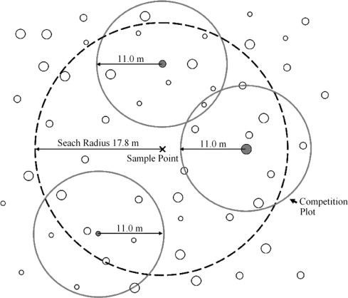

1. [Download : Download full-size image](https://ars.els-cdn.com/content/image/1-s2.0-S0378112711005238-gr1.jpg)

Fig. 1. Schematic of a sample point with three cored trees (solid dots) with various numbers of neighbors (open dots) within their respective competition plots.

We studied the effects of competition on the three most abundant species at LEF: Douglas-fir, ponderosa pine, and western larch. The growth measurements dataset consisted of 285 cored trees (145 Douglas-fir, 99 ponderosa pine, and 41 western larch) ranging in size from 12.7 to 73.2 cm DBH (Fig. 2). Annual radial increments over the last 10 years was measured on the increment cores to the nearest 0.001 mm, using a microscope mounted on a dendrochronometer with a Velmex sliding stage and Accurite measuring system. From the radial increments we computed the average annual basal area increment (BAI; cm<sup>2</sup>/year) over the last 10 years on each cored tree.

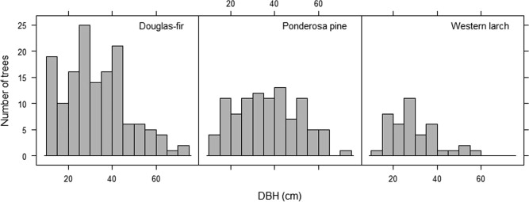

1. [Download : Download full-size image](https://ars.els-cdn.com/content/image/1-s2.0-S0378112711005238-gr2.jpg)

Fig. 2. Diameter at breast height (DBH) distribution of cored trees.

### 2.2. Competition indices

We quantified the competition level experienced by each of the 285 cored trees using the 16 different indices listed in Table 1. The first four indices (CI<sub>1</sub>–CI<sub>4</sub>) are distance-independent, nine are distance-dependent (CI<sub>5</sub>–CI<sub>13</sub>), and three are derived light values used as competition indices (CI<sub>14</sub>–CI<sub>16</sub>). All indices were calculated from the dimensions of the trees within 11 m of each cored tree: some neighbor trees were further than 17.8 m from the original sample point while some trees within 17.8 m of the sample point were not considered (see Fig. 1). Neighbors were only treated as subject trees and different competitor species were not specified. Distance-independent competition indices are often based on plot-centered rather than tree-centered neighborhood data, but tree-centered measures better represent the competition level experienced by the particular tree. In addition, using tree-centered competition plots for each cored tree eliminates edge effect problems associated with distance-dependent competition indices. Furthermore, the indices are intended to be applied to stem-mapped inventory data with complete stand coverage, not to mapped sample-plot data that lack information on off-plot competitors.

Table 1. Sources and mathematical formulas for the competition indices evaluated in this study.

Index

Sources

Equations

*Distance-independent competition indices*

CI<sub>1</sub>

Reineke (1933)

10<sup>(log</sup>*<sup>N</sup>*<sup>+ 1.605 × log</sup>*<sup>dg</sup>*<sup>− 1.605)</sup>

CI<sub>2</sub>

Referred as canopy closure in Rivas et al. (2005)

$(∑i=1n(π×cwi2)/4)/S$

CI<sub>3</sub>

Wykoff et al. (1982)

$(∑j=1n(π×dmaxj2)/4)=BAL$

CI<sub>4</sub>

Schröder and Gadow (1999)

$(1-[1-(BAL/G)])/RS$

*Distance-dependent competition indices*

CI<sub>5</sub>

Number of neighbors

*n*

CI<sub>6</sub>

Gerrard (1969)

$∑i=1nOi/Z$

CI<sub>7</sub>

Bella (1971)

$∑i=1n(Oi×di)/(Z×d)$

CI<sub>8</sub>

Hegyi (1974)

$∑i=1ndi/(d×disti)$

CI<sub>9</sub>

Braathe (1980), cited in Pukkala and Kolström (1987)

$∑i=1nhi/(h×disti)$

CI<sub>10</sub>

Rouvinen and Kuuluvainen (1997)

$∑i=1narctan(di/disti)$

CI<sub>11</sub>

Rouvinen and Kuuluvainen (1997)

$∑i=1n(di/d)×arctan(di/disti)$

CI<sub>12</sub>

Rouvinen and Kuuluvainen (1997)

$∑i=1narctan(hi/disti)$

CI<sub>13</sub>

Rouvinen and Kuuluvainen (1997)

$∑i=1n(hi/h)×arctan(hi/disti)$

*Light values*

CI<sub>14</sub>

Sky’s hemisphere

$(∑i=12160Bi)/2160$

CI<sub>15</sub>

Sky’s hemisphere/sun position

CI<sub>16</sub>

Sun position

$(∑i=163Bi)/108$

*N* trees per ha in the plot; *dg* quadratic mean diameter (cm); *n* number of neighbors within the 11 m radius competition plot; cw*<sub>i</sub>* crown width of the *i*th neighbor tree (m); *S* plot size (m<sup>2</sup>); BAL basal area of neighbor trees larger than the cored tree (m<sup>2</sup> ha<sup>−1</sup>); *G* total basal area of the trees within the 11 m radius plot (m<sup>2</sup> ha<sup>−1</sup>); RS relative spacing index of the plot; *O<sub>i</sub>* area of the influence-zone overlap between the *i*th neighbor tree and the cored tree (m<sup>2</sup>); *Z* area of the influence-zone of the cored tree (m<sup>2</sup>); *d<sub>i</sub>* DBH of the *i*th neighbor tree (cm); *d* DBH of the cored tree (cm); dist*<sub>i</sub>* horizontal distance from the *i*th neighbor tree to the cored tree (m); *h<sub>i</sub>* height of the *i*th neighbor tree (m); *h* height of the cored tree (m); *B<sub>i</sub>* binary variable that is 1 if the *i*th light ray is blocked, or 0 otherwise; *B<sub>Ni</sub>* binary variable associated with north-oriented light rays (azimuths from 270° to 90°), 1 if blocked and 0 otherwise; *B<sub>Si</sub>* binary variable associated with south-oriented light rays (azimuths from 90° to 270°), 1 if blocked and 0 otherwise.

The four selected distance-independent indices have been widely used. CI<sub>1</sub> is Reineke’s (1933) stand density index, based on the number of trees per ha in a competition plot (*N*) and their quadratic mean diameter. CI<sub>2</sub> is canopy closure or the area of the crowns projected on the horizontal plane as a fraction of the competition plot area. CI<sub>3</sub> is the sum of basal areas of neighbor trees larger than the cored tree (BAL) as proposed by Wykoff et al. (1982). CI<sub>4</sub> was proposed by Schröder and Gadow (1999) and is a modification of CI<sub>3</sub> that incorporates relative spacing index (RS):(1)$RS=10,000×NH$where, *H* is dominant height (m), measured in this study as the average height of the tallest 20% of the within 17.8 m of the sample point.

Distance-dependent competition indices were also evaluated owning to their observed utility in many previous studies. CI<sub>5</sub> is a simple measure of competition calculated as the number of neighbor trees inside the competition plot. CI<sub>6</sub> (Gerrard, 1969) and CI<sub>7</sub> (Bella, 1971) are influence-zone overlap indices that assume that the areas (projected on the horizontal plane) over which trees compete for resources are circular (Fig. 3). The radius of these circular areas is usually a function of tree size and calibrated to the expected growing space of open-grown trees (Rivas et al., 2005). To estimate the latter, we used species-specific maximum crown width equations from the Northern Idaho/Inland Empire variant of the Forest Vegetation Simulator (Dixon, 1989 – revised version, June 2009). CI<sub>8</sub> (Hegyi, 1974) and CI<sub>9</sub> (Braathe, 1980) are size-ratio competition indices derived from the hypothesis that the competitive effect of a neighbor tree increases with increasing size and proximity (Tomé and Burkhart, 1989). These two indices use DBH and height as indicators of size, respectively. CI<sub>10</sub> through CI<sub>13</sub> are also size-ratio indices but employ sums of subtended angles (Rouvinen and Kuuluvainen, 1997). CI<sub>10</sub> is the sum of horizontal angles originating from the cored tree center and spanning the DBH of each neighbor tree (Fig. 4). CI<sub>11</sub> is the sum of the horizontal angles multiplied by the ratios of the DBHs of the neighbor and the cored trees. CI<sub>12</sub> sums vertical angles taken from the cored tree’s base to the slope-adjusted top of each neighbor tree (Fig. 5). Similar to CI<sub>11</sub>, CI<sub>13</sub> incorporates the ratios of heights between the cored tree and its neighbors.

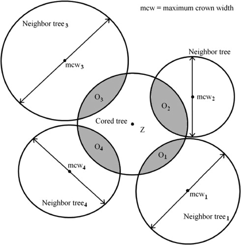

1. [Download : Download full-size image](https://ars.els-cdn.com/content/image/1-s2.0-S0378112711005238-gr3.jpg)

Fig. 3. Influence-zone of a cored tree (*Z*) and areas of influence-zone overlap among the cored tree and four neighbor trees (*O<sub>i</sub>*).

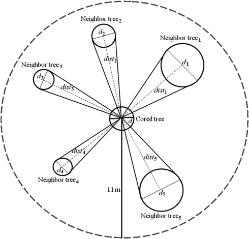

1. [Download : Download full-size image](https://ars.els-cdn.com/content/image/1-s2.0-S0378112711005238-gr4.jpg)

Fig. 4. Schematic of the horizontal angles from a cored tree’s center to the bole (at breast-height) of each neighbor tree within the competition plot used to compute CI<sub>10</sub> and CI<sub>11</sub>.

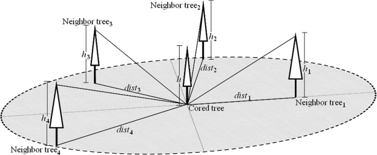

1. [Download : Download full-size image](https://ars.els-cdn.com/content/image/1-s2.0-S0378112711005238-gr5.jpg)

Fig. 5. Schematic of the vertical angles from the base of the cored tree to the top of each neighbor within the competition plot used to compute CI<sub>12</sub> and CI<sub>13</sub>.

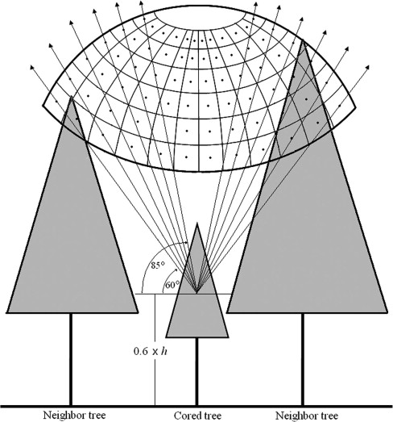

1. [Download : Download full-size image](https://ars.els-cdn.com/content/image/1-s2.0-S0378112711005238-gr6.jpg)

Fig. 6. Discretization of a portion of the sky’s hemisphere directly above the cored tree into 2160 light rays generated from a focal point at 60% of the cored tree’s height.

A computer routine was written in the C computer language to generate light rays and compute light ray interception estimates used in light-value indices. In this routine, a light ray was represented by a linear equation based on; (i) the subject tree location (*x*-, *y*-, and *z*-coords), and (ii) the light ray’ source angles (azimuth and elevation) from the tree’s focal point. The routine then checked if the light ray was blocked by any neighbor tree crowns based on each neighbor tree’s location and crown architecture (e.g., tree height, and crown width). Lastly, the proportion of blocked light rays was computed to obtain estimates of light availability.

### 2.3. Evaluation of competition indices

Exploratory analyses of the competition indices included an examination of Spearman cross-correlations among all 16 indices and BAI. These rank correlations were plotted to permit graphical assessments of the overall dependence structure, species-specific relationships among indices, and the indices’ potential effectiveness as growth predictors. Subsequently, a series of species-specific linear models for log-transformed BAI were fit to quantify the effect of each competition index in combination with other tree growth predictors. The latter included 2008 tree DBH and tree height, as well as site characteristics slope (S), aspect (A), and elevation (E), plus dominant height (H). For model selection purposes, we started with all potential predictors and, through backward selection removed covariates with insignificant contribution (*α* = 0.05). To balance model performance with parsimony, models were compared using the adjusted coefficient of determination $(Ra2)$, which accounts for both the proportion of variability in log BAI explained by the model and the number of covariates in the model.

### 2.4. Basal area increment modeling

The exploratory analyses described above were used to guide the selection of the competition index that, along with other important growth predictors, provided the most accurate estimation of BAI for the three target species. To incorporate this index and other covariates into a predictive model for BAI, a generalized linear modeling (GLM) strategy was employed. GLMs accommodate mean functions that are linear in the predictors only on a transformed scale and can be applied to data that conform to any probability distribution in the exponential family (such as the normal or gamma functions; McCullagh and Nelder, 1989). GLMs permit direct description of the mean of the dependent variable, avoiding the biases accrued when a log-transformed response is modeled and obviating the need for subsequent bias corrections (McCullagh and Nelder, 1989). Non-linear relationships between the covariates and BAI were captured using covariate transformations and a log-link mean function. Also, because the BAI data exhibited an increasing mean–variance relationship, a gamma distribution was used to characterize the error structure. The gamma distribution is a flexible 2-parameter probability density function capable of describing skewed and heteroscedastic continuous data (see e.g., Gea-Izquierdo and Cañellas, 2009).

## 3. Results and discussion

### 3.1. Comparative analysis of competition indices

The cross-correlation structure of the competition indices is presented in Fig. 7. The Spearman correlation matrix shows global correlations and species-specific correlations below and above the diagonal, respectively. Each panel above the diagonal runs from −1 to 1 (left to right) with a vertical line in the middle at zero. A broad range of correlations among different indices is apparent but, in general, within-class correlations are stronger than between-class correlations. For example, the distance-independent indices CI<sub>1</sub>–CI<sub>2</sub> and CI<sub>3</sub>–CI<sub>4</sub>; distance-dependent indices CI<sub>6</sub>–CI<sub>7</sub>, CI<sub>10</sub>–CI<sub>11</sub>, CI<sub>10</sub>–CI<sub>12</sub>, and CI<sub>11</sub>–CI<sub>13</sub>; and light value pairs CI<sub>14</sub>–CI<sub>15</sub>, and CI<sub>15</sub>–CI<sub>16</sub>, are all strongly correlated regardless of species. These results are expected because of the similarities in the indices’ formulations and because of associations among the input variables (e.g., DBH, height) used to assess the size of competitors (see Table 1). More interesting are strong correlations between certain pairings of distance-dependent and distance-independent indices (i.e. CI<sub>3</sub>–CI<sub>11</sub> and CI<sub>4</sub>–CI<sub>11</sub>), whose mathematical formulations are quite different.

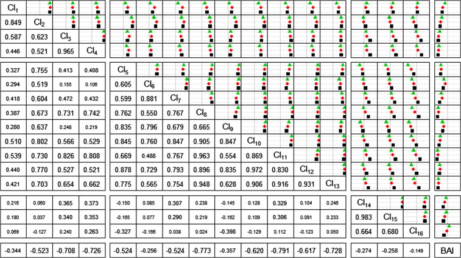

1. [Download : Download full-size image](https://ars.els-cdn.com/content/image/1-s2.0-S0378112711005238-gr7.jpg)

Fig. 7. Spearman rank correlation matrix plot of competition indices and BAI showing species-specific and global correlations above and below the diagonal (Douglas-fir = black squares; ponderosa pine = red circles; western larch = green triangles). (For interpretation of the references to color in this figure legend, the reader is referred to the web version of this article.)

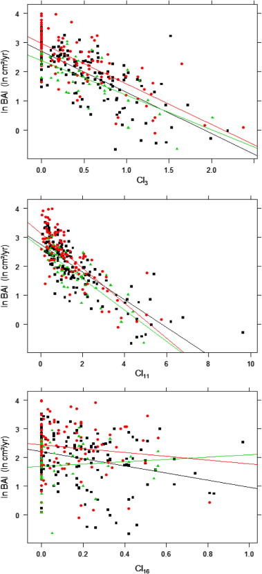

1. [Download : Download full-size image](https://ars.els-cdn.com/content/image/1-s2.0-S0378112711005238-gr8.jpg)

Fig. 8. Scatterplots of ln BAI and three competition indices with species-specific simple linear regressions. (Douglas fir = squares; ponderosa pine = circles; western larch = triangles).

The weak correlations between light values (CI<sub>14</sub>–CI<sub>16</sub>) and tree growth suggests that light may be less of a limiting factor for the established trees (i.e., DBH > 12.5 cm) in our study area and that these trees are competing primarily for soil resources such as water and nutrients. This result is in concordance with other studies reporting soil moisture as the most important growth limiting factor for tree species in the semi-arid conditions of western Montana (Nagel and O’Hara, 2002, Sala et al., 2005, Littell et al., 2008). We observed slightly stronger associations between light values and BAI for Douglas-fir trees in the lower third of the DBH range (DBH < 25.9 cm; *ρ* = −0.39 for CI<sub>14</sub>) and for Douglas-fir trees in the lower third of the relative height range (heights below 70% of dominant height; *ρ* = −0.42 for CI<sub>14</sub>). These partially overlapping classes of Douglas-fir trees contained the bulk of observed light values above 0.5. In contrast, very few of the ponderosa pine or western larch trees in our study had CI<sub>14</sub>, CI<sub>15</sub>, or CI<sub>16</sub> values above 0.5 (see Fig. 8), and more than 50% of the trees of these two shade-intolerant species had 0 values for CI<sub>14</sub> and CI<sub>15</sub>. These divergent distributions reflect the fact that shade-tolerant Douglas-fir is the primary species regenerating in the understory, while shade-intolerant ponderosa pine and western larch are infrequently encountered in subdominant canopy positions.

Alternatively, associations between growth and estimated light values may appear weak because the selected indices failed to accurately capture variability in light availability. Different height percentiles on the cored trees were considered as focal points in determining CI<sub>14</sub>–CI<sub>16</sub>. The 60% position was selected because we wanted to measure light availability at a point within the trees’ crowns and because, when evaluating light values at higher percentiles, most trees yielded zero values indicating 100% light availability. This latter result reflects the generally low stocking of trees above 10 cm DBH at LEF. Overall, cored tree DBH ranged from 12 to 73 cm with light availability estimates varying from 0% to 100% across a range of tree canopy positions, slopes (4–57%), and aspects (from 30° to 340°). Of interest would be the development and application of more detailed light availability models (such as those studied by Canham et al., 2004 or Groot, 2004) to the trees in our study area to determine with more certainty how light availability contributes to overall competitive effects.

Preliminary log-linear models of BAI showed that DBH and competition were the only consistently significant growth predictors among those considered for Douglas-fir and western larch (Table 2). For ponderosa pine, in addition to DBH and competition, elevation and dominant height were retained in many models depending on how competition effects were indexed. This result suggests that growth rates of ponderosa pine are more variable across LEF (Fig. 9) and more strongly tied to site conditions. For the three species, all four distance-independent indices (CI<sub>1</sub> through CI<sub>4</sub>) and most distance-dependent indices (CI<sub>5</sub> through CI<sub>13</sub>, but not CI<sub>6</sub> or CI<sub>9</sub> for ponderosa pine and western larch), explained a significant proportion of the variability in log BAI. As expected owing to the low correlations exhibited in Fig. 7 and the weak associations depicted in Fig. 8, the light values (CI<sub>14</sub> through CI<sub>16</sub>) were insignificant growth predictors and were dropped from the log-linear BAI models for all three species.

Table 2. Retained covariates and fit of selected species-specific linear models for log-transformed BAI; initial covariates in each model consisted of a single competition index, DBH, and the site variables E, H, and S.

| Competition index | Douglas-fir Explanatory variables | Douglas-fir Explanatory variables | Douglas-fir Explanatory variables | Douglas-fir $Ra2$ | Ponderosa pine Explanatory variables | Ponderosa pine Explanatory variables | Ponderosa pine Explanatory variables | Ponderosa pine Explanatory variables | Ponderosa pine Explanatory variables | Ponderosa pine $Ra2$ | Western larch Explanatory variables | Western larch Explanatory variables | Western larch Explanatory variables | Western larch $Ra2$ |
| --- | --- | --- | --- | --- | --- | --- | --- | --- | --- | --- | --- | --- | --- | --- |
| 1 | CI<sub>1</sub> | DBH |  | 0.528 | CI<sub>1</sub> | DBH |  |  |  | 0.619 | CI<sub>1</sub> | DBH |  | 0.585 |
| 2 | CI<sub>2</sub> | DBH |  | 0.598 | CI<sub>2</sub> | DBH | E | H |  | 0.653 | CI<sub>2</sub> | DBH |  | 0.602 |
| 3 | CI<sub>3</sub> | DBH | E | 0.588 | CI<sub>3</sub> | DBH |  |  | S | 0.652 | CI<sub>3</sub> | DBH |  | 0.607 |
| 4 | CI<sub>4</sub> |  | E | 0.594 | CI<sub>4</sub> |  | E |  |  | 0.626 | CI<sub>4</sub> |  | H | 0.583 |
| 5 | CI<sub>5</sub> | DBH |  | 0.553 | CI<sub>5</sub> | DBH | E | H |  | 0.614 | CI<sub>5</sub> | DBH | H | 0.555 |
| 6 | CI<sub>6</sub> | DBH |  | 0.519 |  | DBH | E | H |  | 0.573 |  | DBH |  | 0.464 |
| 7 | CI<sub>7</sub> | DBH |  | 0.608 | CI<sub>7</sub> | DBH | E | H |  | 0.609 | CI<sub>7</sub> | DBH |  | 0.509 |
| 8 | CI<sub>8</sub> | DBH |  | 0.688 | CI<sub>8</sub> | DBH | E | H |  | 0.666 | CI<sub>8</sub> | DBH |  | 0.645 |
| 9 | CI<sub>9</sub> | DBH |  | 0.535 |  | DBH | E | H |  | 0.573 |  | DBH |  | 0.464 |
| 10 | CI<sub>10</sub> | DBH |  | 0.651 | CI<sub>10</sub> | DBH | E | H |  | 0.644 | CI<sub>10</sub> | DBH |  | 0.552 |
| 11 | CI<sub>11</sub> | DBH |  | 0.700 | CI<sub>11</sub> | DBH |  | H |  | 0.713 | CI<sub>11</sub> | DBH |  | 0.716 |
| 12 | CI<sub>12</sub> | DBH |  | 0.631 | CI<sub>12</sub> | DBH | E | H |  | 0.626 | CI<sub>12</sub> | DBH |  | 0.523 |
| 13 | CI<sub>13</sub> | DBH |  | 0.677 | CI<sub>13</sub> | DBH | E | H |  | 0.645 | CI<sub>13</sub> | DBH |  | 0.639 |
| 14 |  | DBH |  | 0.452 |  | DBH | E | H |  | 0.573 |  | DBH |  | 0.464 |
| 15 |  | DBH |  | 0.452 |  | DBH | E | H |  | 0.573 |  | DBH |  | 0.464 |
| 16 |  | DBH |  | 0.452 |  | DBH | E | H |  | 0.573 |  | DBH |  | 0.464 |
| None |  | DBH |  | 0.452 |  | DBH |  |  |  | 0.514 |  | DBH |  | 0.464 |

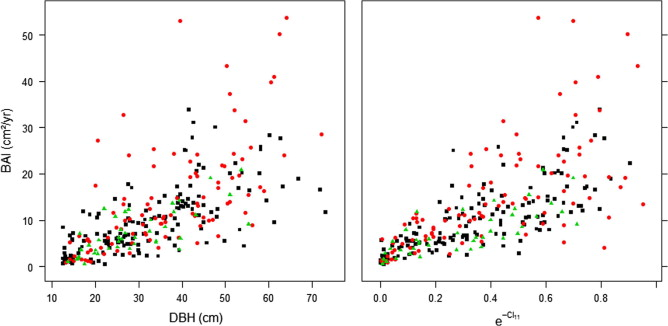

1. [Download : Download full-size image](https://ars.els-cdn.com/content/image/1-s2.0-S0378112711005238-gr9.jpg)

Fig. 9. BAI as a function of DBH and CI<sub>11</sub>. (Douglas fir = squares; ponderosa pine = circles; western larch = triangles).

### 3.2. Basal area increment model

Although the best fitting linear model of log BAI for ponderosa pine included dominant height as a predictor, the contribution of dominant height to the overall predictive power was marginal. Removing it from the model the proportion of variation explained dropped by only 1%. Therefore, to calibrate more parsimonious BAI models for the three species, only the species identifier, DBH, and CI<sub>11</sub> were retained as predictors. On the measurement scale BAI (cm<sup>2</sup>/yr) was approximately linearly to DBH and exponentially decreasing in CI<sub>11</sub>, and also exhibited a positive mean–variance relationship (Fig. 9). Covariate effects were specified using a log-link function for trend while the increasing variance was addressed by fitting a gamma GLM. Species-specific intercepts, DBH effects, and CI<sub>11</sub> effects were initially included in this model, as was an interaction term for multiplicative DBH by CI<sub>11</sub> effects (in the linear predictor). Deviance partitioning tests showed that no evidence of a significant interaction between CI<sub>11</sub> and DBH so this term was dropped. These tests also showed that species-specific DBH effects were insignificant (*α* = 0.05) and, surprisingly, that species-specific CI<sub>11</sub> effects were only marginally significant (*p*-value = 0.05). Thus, species-specific intercept and CI<sub>11</sub> terms were retained in a final species-specific model, but for comparison a combined model with no species-specific terms was also fit.

The individual tree growth models had mean functions of the form(2)$BAI=exp[b0+bDBHln(DBH)+bCICI11]$Values of the intercept (*b*<sub>0</sub>), DBH effect (*b*<sub>DBH</sub>), and CI<sub>11</sub> effect (*b*<sub>CI</sub>) coefficients for both the species-specific and combined models are given in Table 3, along with estimated variance parameters. The use of a gamma GLM to fit these models allowed us to directly model mean annual BAI, thus avoiding biases associated with transformations, and, at least in principle, calibrating more accurate BAI models by accounting for the increasing variance in growth rates among larger and more open-grown trees.

Table 3. Species-specific and combined model coefficients (standard errors in parentheses), variance parameters (*v*), and fit statistics.

[output not shown]

The fit of the species-specific model indicates that after accounting for DBH and competition effects, ponderosa pine exhibited the highest growth rates overall and western larch the lowest (Table 3). Also, ponderosa pine showed the greatest sensitivity to increasing competition (as measured by increasing values of CI<sub>11</sub>) and the more shade-tolerant Douglas-fir the least. These results parallel the patterns in Fig. 8 (middle panel). Interestingly, the combined model had a root mean square error (RMSE) only 7% larger than the species-specific model (Table 3), despite collapsing the intercept and CI<sub>11</sub> effects to singular values. Plots of deviance residuals revealed no discernible structure in either model with the exception of a slight tendency to overestimate the BAI of the fastest growing trees.

We anticipate applying these models to stem-mapped data derived from LiDAR acquisitions for LEF and surrounding areas. Initial analyzes of these stem maps indicate that tree location and DBH attributes are relatively reliable but that species identification is weak or lacking (Suratno et al., 2009). Thus, the inclusion of species-specific terms in a BAI model may be of little practical advantage. Our combined model ultimately uses only the subject tree’s DBH as well as the DBHs and distances of neighbor trees within 11 m to predict growth, both of which are a component of the LiDAR-derived stem maps available for LEF. Our model will be useful to simulate tree growth, and particular, to capture temporal and spatial effects of alternative fuel reduction treatments and optimize the selection of tree removal for reducing the risk of high-intensity wildfire over time (see Contreras, 2010).

Forest growth models are typically condition on the state of the forest at the beginning of a growth period and project that state forward. In this study, we examined the relationship between competition indices based on state variables measured in 2008 and growth over the period 1998–2007. It was not possible to estimate competition levels in LEF in 1998 because of the lack of a permanent plot database. Models developed from state variables measured at the beginning or at the end of a growth period will suffer a comparable lack of precision due to changes in trees’ competitive regimes throughout the period. Yet in both cases, changes in the competitive regimes should have a similar effect across competition indices and thus would not bias our assessment of the indices’ relative predictive powers. We recognize that our retrospective approach (measuring state variable at the end of the growing period) will likely bias downwards the estimates of future periodic growth if the model is applied in a prospective manner (i.e., if values for CI<sub>11</sub> are obtained from state variables at the start of a projection period). Nonetheless, there is a pressing need for individual tree growth models for these commercial species in western Montana and our BAI models provide important provisionary instruments. The sample points used in this study were selected to establish a permanent plot network, and in time will supply data for modeling growth prospectively and for assessing the accuracy of the models developed above.

When applying our models to estimate the BAI of trees tallied in a plot-based inventory, edge correction procedures will need to be applied unless off-plot data are available. As our competition measures and basal area growth model are based on tree-centered definitions of competition intensity, the model is best suited for growing trees in stands with complete spatial inventory information derived from technologies such as LiDAR. Independent of the study area, the increasing availability of this tree-level inventory offers the opportunity of measuring and using competition in a more tree-center manner that can capture competition levels experienced by individual trees more specifically that distance-independent indices. Finally, in this study we were interested primarily in modeling short-term tree growth and we did not account for dynamic processes such as mortality and regeneration. These processes as well as other events such as fire occurrence and insect attack alter tree density and consequently tree competition levels. For these reasons and because of the potential for changing climatic conditions moving forward, the models developed here from past growth records are not suited to long-term growth estimations.

## 4. Conclusions

We evaluated 16 measures of tree competition in terms of their effectiveness as growth predictors for three important conifer tree species in western Montana. We found strong correlations between several competition indices and tree growth indicating that competition exists and that it is important for all three species. Several distance-dependent competition indices were more strongly correlated with growth, with the best of them explaining a larger proportion of growth variation than the best distance-independent index (64% vs. 56%). These results indicate that competition occurs at the local level and that variable tree densities and relatively complex stand structures create heterogeneous conditions within the study area. Low correlations between light-value indices and growth suggest that the established trees in the semi-arid conditions of our study area are not competing primarily for light. However, more sophisticated light availability models could be evaluated to determine what aspects of light availability are not captured by traditional competition indices and the extent to which variability in light availability affects the growth of sapling and established trees in this area.

Our results show that distance-dependent competition indices better describe the variable tree neighborhoods maintained by complex stands structures common in western Montana. A disadvantage of distance-dependent competition indices is the need for tree attributes and tree locations that are expensive and labor intensive to acquire. Yet advances in remote sensing and geographic information systems such as LiDAR have facilitated the acquisition of tree level inventory data for entire stands and are becoming more available for forest and natural resources applications in the inland northwest. The DBH and distance-dependent BAI models calibrated in this study can be readily integrated with LiDAR inventory data and will be a useful tool to assess the effects of alternative management actions over time. As such, they offer the potential for more credible simulation and more efficient planning of fuel hazard reduction thinnings applied across the forests of western Montana.

## References

**Bella, 1971**

I.E. Bella

**A new competition model for individual trees**

For. Sci., 17 (1971), pp. 364-372

[Google Scholar](https://scholar.google.com/scholar_lookup?title=A%20new%20competition%20model%20for%20individual%20trees&publication_year=1971&author=I.E.%20Bella)

**Biging and Dobbertin, 1992**

G.S. Biging, M. Dobbertin

**A comparison of distance-dependent competition measures for height and basal area growth of individual conifer trees**

For. Sci., 38 (1992), pp. 695-720

Google Scholar

**Biging and Dobbertin, 1995**

G.S. Biging, M. Dobbertin

**Evaluation of competition indices in individual tree growth models**

For. Sci., 41 (1995), pp. 360-377

[Google Scholar](https://scholar.google.com/scholar_lookup?title=Evaluation%20of%20competition%20indices%20in%20individual%20tree%20growth%20models&publication_year=1995&author=G.S.%20Biging&author=M.%20Dobbertin)

**Boivin et al., 2010**

F. Boivin, A. Paquette, M.J. Papaik, N. Thiffault, C. Messier

**Do position and species identity of neighbors matter in 8–15-year-old post harvest mesic stands in the boreal mixedwood?**

For. Ecol. Manage., 260 (2010), pp. 1124-1131

[Article](https://www.sciencedirect.com/science/article/pii/S0378112710003695)[Download PDF](https://www.sciencedirect.com/science/article/pii/S0378112710003695/pdfft?md5=b86cedd210054e84ad60ea0b392e3437&pid=1-s2.0-S0378112710003695-main.pdf)[View Record in Scopus](https://www.scopus.com/inward/record.url?eid=2-s2.0-77955774207&partnerID=10&rel=R3.0.0)[Google Scholar](https://scholar.google.com/scholar?q=Do%20position%20and%20species%20identity%20of%20neighbors%20matter%20in%20815-year-old%20post%20harvest%20mesic%20stands%20in%20the%20boreal%20mixedwood)

**Braathe, 1980**

P. Braathe

**Height increment of young single trees in relation to height and distance of neighboring trees**

Mitt. Forstl. VersAnst., 130 (1980), pp. 43-48

[View Record in Scopus](https://www.scopus.com/inward/record.url?eid=2-s2.0-0011383922&partnerID=10&rel=R3.0.0)Google Scholar

**Brunner, 1998**

A. Brunner

**A light model for spatially explicit forest stand models**

For. Ecol. Manage., 107 (1998), pp. 19-46

[Article](https://www.sciencedirect.com/science/article/pii/S0378112797003253)[Download PDF](https://www.sciencedirect.com/science/article/pii/S0378112797003253/pdfft?md5=ae216698b53801f1d84349932ce1e628&pid=1-s2.0-S0378112797003253-main.pdf)[View Record in Scopus](https://www.scopus.com/inward/record.url?eid=2-s2.0-0032541374&partnerID=10&rel=R3.0.0)[Google Scholar](https://scholar.google.com/scholar_lookup?title=A%20light%20model%20for%20spatially%20explicit%20forest%20stand%20models&publication_year=1998&author=A.%20Brunner)

**Canham et al., 2004**

C.D. Canham, P.T. LePage, K.D. Coates

**A neighborhood analysis of canopy tree competition: effects of shading versus crowding**

Can. J. For. Res., 34 (2004), pp. 778-787

[View Record in Scopus](https://www.scopus.com/inward/record.url?eid=2-s2.0-3042602359&partnerID=10&rel=R3.0.0)Google Scholar

**Coates et al., 2009**

K.D. Coates, C.D. Canham, C.T. LePage

**Above versus belowground competitive effects and responses of a guild of temperate tree species**

J. Ecol., 97 (2009), pp. 118-130

[CrossRef](https://doi.org/10.1111/j.1365-2745.2008.01458.x)[View Record in Scopus](https://www.scopus.com/inward/record.url?eid=2-s2.0-57649118576&partnerID=10&rel=R3.0.0)Google Scholar

**Contreras, 2010**

Contreras, M.A., 2010. Spatio-temporal optimization of tree removal to efficiently minimize crown fire potential. PhD dissertation, Department of Forest Management, College of Forestry and Conservation, The University of Montana, Missoula, MT, p. 183.

Google Scholar

**Contreras and Chung, 2011**

M.A. Contreras, W. Chung

**A modeling approach to estimating skidding costs for individual trees for thinning operations**

West. J. Appl. For., 26 (2011), pp. 133-146

[CrossRef](https://doi.org/10.1093/wjaf/26.3.133)[View Record in Scopus](https://www.scopus.com/inward/record.url?eid=2-s2.0-79959701869&partnerID=10&rel=R3.0.0)Google Scholar

**Daniels et al., 1986**

R.F. Daniels, H.E. Burkhart, T.R. Clason

**A comparison of competition measures for predicting growth of loblolly pine trees**

Can. J. For. Res., 16 (1986), pp. 1230-1237

[CrossRef](https://doi.org/10.1139/x86-218)[View Record in Scopus](https://www.scopus.com/inward/record.url?eid=2-s2.0-0022844395&partnerID=10&rel=R3.0.0)Google Scholar

**De Luis et al., 1998**

M. De Luis, J. Raventós, J. Cortina, M.J. Moro, J. Bellot

**Assessing components of a competition index to predict growth in an even-aged *Pinus nigra* stand**

New For., 15 (1998), pp. 223-242

[View Record in Scopus](https://www.scopus.com/inward/record.url?eid=2-s2.0-0032080094&partnerID=10&rel=R3.0.0)Google Scholar

**Dixon, 1989**

Dixon, G.E., 1989. Northern Idaho/Inland Empire (NI/IE) Variants Overview. Forest Vegetation Simulator. USDA For. Serv. Forest Management Service Center, p. 51, Revised version (June 2009).

Google Scholar

**Gea-Izquierdo and Cañellas, 2009**

G. Gea-Izquierdo, I. Cañellas

**Analysis of Holm Oak intraspecific competition using gamma regression**

For. Sci., 55 (2009), pp. 310-322

[View Record in Scopus](https://www.scopus.com/inward/record.url?eid=2-s2.0-70349611064&partnerID=10&rel=R3.0.0)[Google Scholar](https://scholar.google.com/scholar_lookup?title=Analysis%20of%20Holm%20Oak%20intraspecific%20competition%20using%20gamma%20regression&publication_year=2009&author=G.%20Gea-Izquierdo&author=I.%20Ca%C3%B1ellas)

**Gerrard, 1969**

D.I. Gerrard

**Competition quotient: a new measure for the competition affecting individual forest trees. Michigan State University**

Agric. Res. Station Res. Bull., 20 (1969), pp. 1-32

[View Record in Scopus](https://www.scopus.com/inward/record.url?eid=2-s2.0-0003267864&partnerID=10&rel=R3.0.0)Google Scholar

**Groot, 2004**

A. Groot

**A model to estimate light interception by tree crows, applied to black spruce**

Can. J. For. Res., 34 (2004), pp. 788-799

[View Record in Scopus](https://www.scopus.com/inward/record.url?eid=2-s2.0-3042595759&partnerID=10&rel=R3.0.0)[Google Scholar](https://scholar.google.com/scholar_lookup?title=A%20model%20to%20estimate%20light%20interception%20by%20tree%20crows%2C%20applied%20to%20black%20spruce&publication_year=2004&author=A.%20Groot)

**Habeck, 1994**

J.R. Habeck

**Using General Land Office records to assess forest succession in ponderosa pine/Douglas-fir forests in western Montana**

Northwest Sci., 68 (1994), pp. 69-78

[View Record in Scopus](https://www.scopus.com/inward/record.url?eid=2-s2.0-0028160062&partnerID=10&rel=R3.0.0)[Google Scholar](https://scholar.google.com/scholar?q=Using%20General%20Land%20Office%20records%20to%20assess%20forest%20succession%20in%20ponderosa%20pineDouglas-fir%20forests%20in%20western%20Montana)

**Hegyi, 1974**

Hegyi, F., 1974. A simulation model for managing jackpine stands. In: Fries, J. (Ed.), Proceedings of IUFRO meeting S4.01.04 on Growth models for tree and stand simulation, Royal College of Forestry, Stockolm.

Google Scholar

**Holmes and Reed, 1991**

M.J. Holmes, D.D. Reed

**Competition indices for mixed species northern hardwoods**

For. Sci., 37 (1991), pp. 1338-1349

[View Record in Scopus](https://www.scopus.com/inward/record.url?eid=2-s2.0-0001196641&partnerID=10&rel=R3.0.0)[Google Scholar](https://scholar.google.com/scholar_lookup?title=Competition%20indices%20for%20mixed%20species%20northern%20hardwoods&publication_year=1991&author=M.J.%20Holmes&author=D.D.%20Reed)

**Keane et al., 2002**

R.E. Keane, K.C. Ryan, T.T. Veblen, C.D. Allen, J. Logan, B. Hawkes

**Cascading effects of fire exclusion in the Rocky Mountain ecosystems**

USDA For. Serv. Gen. Tech. Rep. RMRS-91 (2002), p. 24

[View Record in Scopus](https://www.scopus.com/inward/record.url?eid=2-s2.0-84892479566&partnerID=10&rel=R3.0.0)Google Scholar

**Keddy, 1989**

P.A. Keddy

**Competition**

Chapman and Hall, London (1989)

[Google Scholar](https://scholar.google.com/scholar_lookup?title=Competition&publication_year=1989&author=P.A.%20Keddy)

**Korzukhin and Ter-Mikaelian, 1995**

M.D. Korzukhin, M.T. Ter-Mikaelian

**An individual tree-based model of competition for light**

Ecol. Model., 79 (1995), pp. 221-229

[Article](https://www.sciencedirect.com/science/article/pii/030438009400039K)[Download PDF](https://www.sciencedirect.com/science/article/pii/030438009400039K/pdf?md5=72649f79de3903cbc809d4cceb29b563&pid=1-s2.0-030438009400039K-main.pdf)[View Record in Scopus](https://www.scopus.com/inward/record.url?eid=2-s2.0-0028992721&partnerID=10&rel=R3.0.0)[Google Scholar](https://scholar.google.com/scholar_lookup?title=An%20individual%20tree-based%20model%20of%20competition%20for%20light&publication_year=1995&author=M.D.%20Korzukhin&author=M.T.%20Ter-Mikaelian)

**Lederman, 2010**

T. Lederman

**Evaluating the performance of semi-distance-independent competition indices in predicting the basal area growth of individual trees**

Can. J. For. Res., 40 (2010), pp. 796-805

Google Scholar

**Littell et al., 2008**

J.S. Littell, D.V. Peterson, M. Tjolker

**Douglas-fir growth in mountain ecosystem: water limits tree growth from stand to region**

Ecol. Monogr., 78 (2008), pp. 349-368

[CrossRef](https://doi.org/10.1890/07-0712.1)[View Record in Scopus](https://www.scopus.com/inward/record.url?eid=2-s2.0-63849168984&partnerID=10&rel=R3.0.0)Google Scholar

**Lorimer, 1983**

C.G. Lorimer

**Tests of age-independent competition indices for individual trees in natural hardwood stands**

For. Ecol. Manage., 6 (1983), pp. 343-360

[Article](https://www.sciencedirect.com/science/article/pii/0378112783900427)[Download PDF](https://www.sciencedirect.com/science/article/pii/0378112783900427/pdf?md5=ebb6f5232734f173c2aebde124bcc085&pid=1-s2.0-0378112783900427-main.pdf)[View Record in Scopus](https://www.scopus.com/inward/record.url?eid=2-s2.0-0020926902&partnerID=10&rel=R3.0.0)[Google Scholar](https://scholar.google.com/scholar_lookup?title=Tests%20of%20age-independent%20competition%20indices%20for%20individual%20trees%20in%20natural%20hardwood%20stands&publication_year=1983&author=C.G.%20Lorimer)

**MacKenzie et al., 2004**

M.D. MacKenzie, T.H. DeLuca, A. Sala

**Forest structure and organic horizon analysis along a fire chronosequence in the low elevation forests of western Montana**

For. Ecol. Manage., 203 (2004), pp. 331-343

[Article](https://www.sciencedirect.com/science/article/pii/S0378112704005717)[Download PDF](https://www.sciencedirect.com/science/article/pii/S0378112704005717/pdfft?md5=0f8babfb66856922b55a2a9e320c4581&pid=1-s2.0-S0378112704005717-main.pdf)[View Record in Scopus](https://www.scopus.com/inward/record.url?eid=2-s2.0-8844250201&partnerID=10&rel=R3.0.0)Google Scholar

**Maltamo et al., 2004**

M. Maltamo, K. Mustonen, J. Hyyppä, J. Pitkänen, X. Yu

**The accuracy of estimating individual tree variables with airborne laser scanning in a boreal nature reserve**

Can. J. For. Res., 34 (2004), pp. 1791-1801

[View Record in Scopus](https://www.scopus.com/inward/record.url?eid=2-s2.0-9944260989&partnerID=10&rel=R3.0.0)Google Scholar

**Martin and Ek, 1984**

G.L. Martin, A.R. Ek

**A comparison of competition measures and growth models for predicting plantation red pine diameter and height growth**

For. Sci., 30 (1984), pp. 731-743

[View Record in Scopus](https://www.scopus.com/inward/record.url?eid=2-s2.0-0021539720&partnerID=10&rel=R3.0.0)Google Scholar

**McCullagh and Nelder, 1989**

P. McCullagh, J.A. Nelder

**Generalized Linear Models**

Chapman & Hall, London, UK (1989)

[Google Scholar](https://scholar.google.com/scholar_lookup?title=Generalized%20Linear%20Models&publication_year=1989&author=P.%20McCullagh&author=J.A.%20Nelder)

**Miina and Pukkala, 2002**

J. Miina, T. Pukkala

**Application of ecological field theory in distance-dependent growth modeling**

For. Ecol. Manage., 161 (2002), pp. 101-107

[Article](https://www.sciencedirect.com/science/article/pii/S0378112701004893)[Download PDF](https://www.sciencedirect.com/science/article/pii/S0378112701004893/pdfft?md5=8039e68af1ce025e323ab9ca8d2dca5f&pid=1-s2.0-S0378112701004893-main.pdf)[View Record in Scopus](https://www.scopus.com/inward/record.url?eid=2-s2.0-0037093751&partnerID=10&rel=R3.0.0)[Google Scholar](https://scholar.google.com/scholar_lookup?title=Application%20of%20ecological%20field%20theory%20in%20distance-dependent%20growth%20modeling&publication_year=2002&author=J.%20Miina&author=T.%20Pukkala)

**Moore et al., 1973**

J.A. Moore, C.A. Budelsky, R.C. Schlesinger

**A new index representing individual tree competitive status**

Can. J. For. Res., 3 (1973), pp. 495-505

[CrossRef](https://doi.org/10.1139/x73-073)[View Record in Scopus](https://www.scopus.com/inward/record.url?eid=2-s2.0-0001169411&partnerID=10&rel=R3.0.0)Google Scholar

**Nagel and O’Hara, 2002**

L.M. Nagel, K.L. O’Hara

**Diurnal fluctuations in gas exchange and water potential in different stand structure of *Pinus ponderosa***

Trees, 16 (2002), pp. 281-290

[View Record in Scopus](https://www.scopus.com/inward/record.url?eid=2-s2.0-0036587097&partnerID=10&rel=R3.0.0)Google Scholar

**National Climatic Data Center, 2004**

National Climatic Data Center, 2004. Climatography of the United States No. 20, 1971–2000: Potomoc, MT. Available online at [www.ncdc.noaa.gov](http://www.ncdc.noaa.gov/) (accessed 18.04.11).

Google Scholar

**Nimlos, 1986**

Nimlos, T.J., 1986. Soils of Lubrecht Experimental Forest. Montana Forest and Conservation Experiment Station Miscellaneous Publication No. 44.

Google Scholar

**Packalén and Maltamo, 2006**

P. Packalén, M. Maltamo

**Predicting the plot volume by species using airborne laser scanning and aerial photographs**

For. Sci., 52 (2006), pp. 611-622

[View Record in Scopus](https://www.scopus.com/inward/record.url?eid=2-s2.0-33845573157&partnerID=10&rel=R3.0.0)Google Scholar

**Pfister, 1977**

Pfister, R.D., Kovalchik, B.L., Arno, S.F., Presby, R.C. 1977. Forest Habitat Types of Montana. USDA For. Serv. Gen. Tech. Rep. INT-GTR-34.

Google Scholar

**Pukkala and Kolström, 1987**

T. Pukkala, T. Kolström

**Competition indices and the prediction of radial growth in Scots pine**

Silva Fenn., 21 (1987), pp. 55-67

[View Record in Scopus](https://www.scopus.com/inward/record.url?eid=2-s2.0-0002545568&partnerID=10&rel=R3.0.0)[Google Scholar](https://scholar.google.com/scholar_lookup?title=Competition%20indices%20and%20the%20prediction%20of%20radial%20growth%20in%20Scots%20pine&publication_year=1987&author=T.%20Pukkala&author=T.%20Kolstr%C3%B6m)

**Radtke et al., 2003**

P.J. Radtke, J.A. Westfall, H.E. Burkhart

**Conditioning a distance-dependent competition index to indicate the onset of inter-tree competition**

For. Ecol. Manage., 175 (2003), pp. 17-30

[Article](https://www.sciencedirect.com/science/article/pii/S0378112702001184)[Download PDF](https://www.sciencedirect.com/science/article/pii/S0378112702001184/pdfft?md5=be7837136e3055084ce0d893492e6859&pid=1-s2.0-S0378112702001184-main.pdf)[View Record in Scopus](https://www.scopus.com/inward/record.url?eid=2-s2.0-0037416125&partnerID=10&rel=R3.0.0)Google Scholar

**Reineke, 1933**

L.H. Reineke

**Perfecting a stand density index for even-aged forest**

J. Agric. Res., 46 (1933), pp. 627-638

[Google Scholar](https://scholar.google.com/scholar_lookup?title=Perfecting%20a%20stand%20density%20index%20for%20even-aged%20forest&publication_year=1933&author=L.H.%20Reineke)

**Rivas et al., 2005**

J.J.C. Rivas, J.G. Gonzàlez, O. Aguirre, F.G. Hernàndez

**The effect of competition on individual tree basal area growth in mature stands of *Pinus cooperi* Blanco in Durango (Mexico)**

Eur. J. For. Res., 124 (2005), pp. 133-142

[CrossRef](https://doi.org/10.1007/s10342-005-0061-y)[View Record in Scopus](https://www.scopus.com/inward/record.url?eid=2-s2.0-21444450634&partnerID=10&rel=R3.0.0)[Google Scholar](https://scholar.google.com/scholar?q=The%20effect%20of%20competition%20on%20individual%20tree%20basal%20area%20growth%20in%20mature%20stands%20of%20Pinus%20cooperi%20Blanco%20in%20Durango)

**Rouvinen and Kuuluvainen, 1997**

S. Rouvinen, T. Kuuluvainen

**Structure and asymmetry of tree crowns in relation to local competition in a natural mature Scot pine forest**

Can. J. For. Res., 27 (1997), pp. 890-902

[View Record in Scopus](https://www.scopus.com/inward/record.url?eid=2-s2.0-0030802707&partnerID=10&rel=R3.0.0)Google Scholar

**Rowell et al., 2009**

Rowell, E., Seielstad, C., Goodburn, J., Queen, L. 2009. Estimating plot-scale biomass in a western North American mixed-conifer forest from lidar-derived tree stems. Silvilaser 2009. Proceedings of the Ninth International Conference on Lidar Applications for Assessing Forest Ecosystems. Texas A&M University, October 15, 2009.

Google Scholar

**Sala et al., 2005**

A. Sala, G.D. Peters, L.R. McIntyre, M.G. Harrington

**Physiological responses of ponderosa pine in western Montana to thinning, prescribed burning, and burning season**

Tree Physiol., 25 (2005), pp. 339-348

[CrossRef](https://doi.org/10.1093/treephys/25.3.339)[View Record in Scopus](https://www.scopus.com/inward/record.url?eid=2-s2.0-16244414682&partnerID=10&rel=R3.0.0)Google Scholar

**Schröder and Gadow, 1999**

J. Schröder, K.V. Gadow

**Testing a new competition index for Maritime pine in northwestern Spain**

Can. J. For. Res., 29 (1999), pp. 280-283

[View Record in Scopus](https://www.scopus.com/inward/record.url?eid=2-s2.0-0032915836&partnerID=10&rel=R3.0.0)[Google Scholar](https://scholar.google.com/scholar_lookup?title=Testing%20a%20new%20competition%20index%20for%20Maritime%20pine%20in%20northwestern%20Spain&publication_year=1999&author=J.%20Schr%C3%B6der&author=K.V.%20Gadow)

**Stage and Ledermann, 2008**

A.R. Stage, T. Ledermann

**Effects of competitor spacing in a new class of individual-tree indices of competition: semi-distance-independent indices computed for Bitterlich versus fixed-area plots**

Can. J. For. Res., 38 (2008), pp. 890-898

[View Record in Scopus](https://www.scopus.com/inward/record.url?eid=2-s2.0-43549095204&partnerID=10&rel=R3.0.0)Google Scholar

**Suratno et al., 2009**

A. Suratno, C. Seielstad, L. Queen

**Tree species identification in mixed coniferous forest using laser scanning**

ISPRS J. Photogrammetry Remote Sensing, 64 (2009), pp. 683-693

[Article](https://www.sciencedirect.com/science/article/pii/S0924271609000872)[Download PDF](https://www.sciencedirect.com/science/article/pii/S0924271609000872/pdfft?md5=6e4495b0c4129fe95f716fa2a00e722e&pid=1-s2.0-S0924271609000872-main.pdf)[View Record in Scopus](https://www.scopus.com/inward/record.url?eid=2-s2.0-70350617798&partnerID=10&rel=R3.0.0)Google Scholar

**Tomé and Burkhart, 1989**

M. Tomé, H.E. Burkhart

**Distance-dependent competition measures for predicting growth of individual trees**

For. Sci., 35 (1989), pp. 816-831

[View Record in Scopus](https://www.scopus.com/inward/record.url?eid=2-s2.0-0024944440&partnerID=10&rel=R3.0.0)Google Scholar

**Uzoh and Oliver, 2008**

F.C. Uzoh, W.W. Oliver

**Individual tree diameter increment model for managed even-aged stands of ponderosa pine throughout the western United States using a multilevel linear mixed effects model**

For. Ecol. Manage., 256 (2008), pp. 438-445

[Article](https://www.sciencedirect.com/science/article/pii/S0378112708003873)[Download PDF](https://www.sciencedirect.com/science/article/pii/S0378112708003873/pdfft?md5=e26050db2411578735fe38862bc30ce6&pid=1-s2.0-S0378112708003873-main.pdf)[View Record in Scopus](https://www.scopus.com/inward/record.url?eid=2-s2.0-45849141566&partnerID=10&rel=R3.0.0)Google Scholar

**Woodall et al., 2003**

C.W. Woodall, C.E. Fiedler, K.S. Milner

**Intertree competition in uneven-aged ponderosa pine stands**

Can. J. For. Res., 33 (2003), pp. 1719-1726

[View Record in Scopus](https://www.scopus.com/inward/record.url?eid=2-s2.0-0344065106&partnerID=10&rel=R3.0.0)[Google Scholar](https://scholar.google.com/scholar_lookup?title=Intertree%20competition%20in%20uneven-aged%20ponderosa%20pine%20stands&publication_year=2003&author=C.W.%20Woodall&author=C.E.%20Fiedler&author=K.S.%20Milner)

**Wykoff, 1990**

W.R. Wykoff

**A basal area increment model for individual conifers in northern Rocky Mountains**

For. Sci., 36 (1990), pp. 1077-1104

[View Record in Scopus](https://www.scopus.com/inward/record.url?eid=2-s2.0-0025680587&partnerID=10&rel=R3.0.0)[Google Scholar](https://scholar.google.com/scholar_lookup?title=A%20basal%20area%20increment%20model%20for%20individual%20conifers%20in%20northern%20Rocky%20Mountains&publication_year=1990&author=W.R.%20Wykoff)

**Wykoff et al., 1982**

W.R. Wykoff, N.L. Crookston, A.R. Stage

**User’s guide to the stand prognosis model**

USDA For. Serv. Gen. Tech. Rep. INT-133. (1982), p. 119 p

[Google Scholar](https://scholar.google.com/scholar?q=Users%20guide%20to%20the%20stand%20prognosis%20model)

**<sup>1</sup>**

<http://www.solardat.uoregon.edu/SunChartProgram.html>.

[View Abstract](https://www.sciencedirect.com/science/article/abs/pii/S0378112711005238)

Copyright © 2011 Elsevier B.V. All rights reserved.